# chromVAR-v3

```r
library(repr)
options(repr.plot.width=6, repr.plot.height=5)
```

if (!requireNamespace("BiocManager", quietly = TRUE)) install.packages("BiocManager") BiocManager::install("Rsamtools")

```r
library(tidyverse)
library(chromVAR)
library(motifmatchr)
library(Matrix)
library(SummarizedExperiment)
library(BSgenome.Hsapiens.UCSC.hg38)
library(pheatmap)
library(TFBSTools)
library(BiocParallel)
register(MulticoreParam(10))
set.seed(2019)
```

```r
setwd("/gpfs/commons/groups/sanjana_lab/cdai/TFscreen/atac/")
```

# chromVAR analysis 1 - chromVAR + Jaspar 2020 motifs

**Inputs**

1. *Peaks*: These are peaks centered at summit with uniform width of 500 bp as recommended by chromVAR. Files are under `/gpfs/commons/groups/sanjana_lab/cdai/TFscreen/atac/diffbind_consensu_min2overlap.bed`. First 3 columns are standard bed, the 4th column is peak intensity as calculated from MACS2.
2. *Annovation*: Jaspar 2020 motifs

```r
samplesheet <- read.csv('samplesheet2.csv', stringsAsFactors = F)

# Peaks
peak.file <- "/c/groups/sanjana_lab/cdai/TFscreen/atac/diffbind/diffbind_consensu_min2overlap.bed"
peaks <- getPeaks(peak.file, sort_peaks = T)
```

```r
peaks <- resize(peaks, width = 500, fix = "center")

my_counts_matrix <- read.table("diffbind/diffbind_consensu_min2overlap_readcounts.txt", header = T) %>% as.matrix

depth <- apply(my_counts_matrix, 2, sum)
colData <- column_to_rownames(samplesheet, 'SampleID')
colData <- add_column(colData, depth) # add read depth per sample

fragment_counts <- SummarizedExperiment(assays = list(counts = my_counts_matrix),
                                        rowRanges = peaks, colData = colData)

fragment_counts.addGC <- addGCBias(fragment_counts, genome = BSgenome.Hsapiens.UCSC.hg38)

# each peak must have at least 10 reads across all 12 samples to be included
fragment_counts.filtered <- filterPeaks(fragment_counts.addGC, min_fragments_per_peak = 10,
                                       non_overlapping = T)
```

```r
#make a grange object of normalized atac-seq counts
my_counts_matrix.norm <- apply(my_counts_matrix, MARGIN = 2, function(x) x * 1000000/sum(x))
my_counts_matrix.norm <- peaks %>% as.data.frame %>% cbind(my_counts_matrix.norm) %>% GenomicRanges::makeGRangesFromDataFrame(keep.extra.columns = T)
```

#### Annotations

Get JASPAR2020 motifs. Then construct a motif - gene_name lookup table. In addition, add columns to indicate if a motif is a TF or hit TF.

# method to get JASPAR2018, no used here opts <- list() opts[["species"]] <- "Homo sapiens" jaspar_motifs <- getMatrixSet(JASPAR2018, opts)

```r
# New method: use downloaded JASPAR2020
jaspar_2020 <- readJASPARMatrix("JASPAR2020_combined_matrices_20191030.txt", matrixClass = "PFM")

#120 hit list
hitlist <- read.csv('/c/groups/sanjana_lab/cdai/TFscreen/Hitlist_20191230.csv', header = T, stringsAsFactors = F) %>% pull(hgnc_symbol)
#TF list
tflist <- read.csv('/c/groups/sanjana_lab/cdai/TFscreen/TFlist_20191230.csv', stringsAsFactors = F) %>% pull(hgnc_symbol)
```

```r
# construct base motif_lookup table
motif_lookup <- TFBSTools::name(jaspar_2020) %>%
                data.frame(stringsAsFactors = F) %>%
                rownames_to_column("motif") %>%
                mutate(gene_name=str_extract(`.`, "[a-zA-Z:0-9\\-]+")) %>%
                select(motif, gene_name)

# function to check if a tf name is in the substring of jaspar name
mystrfunc <- function(stringA, target) {
    # string A is a possible gene name, scalar
    # target is a vector of proper gene names
    # match if any target is a substring in string A, if so return True
    stringA <- rep(stringA, length(target))
    test <- unlist(map2(stringA, target, ~ str_detect(.x, .y)))
    return(any(test))
}

#motif_lookup <- motif_lookup  %>% mutate(is_hit = map(gene_name, ~ if_else(mystrfunc(.x, hitlist), "Yes", "No"))) %>%
                 #mutate(is_tf = map(gene_name, ~ if_else(mystrfunc(.x, tflist), "Yes", "No")))

is_hit <- map(motif_lookup$gene_name, ~ if_else(mystrfunc(.x, hitlist), "Yes", "No")) %>% unlist
is_tf <- map(motif_lookup$gene_name, ~ if_else(mystrfunc(.x, tflist), "Yes", "No")) %>% unlist

motif_lookup <- motif_lookup %>% add_column(is_hit = is_hit, is_tf = is_tf)
```

#### Deviations

```r
# get motif matches with peaks
motif_ix <- matchMotifs(jaspar_2020, fragment_counts.filtered, genome = BSgenome.Hsapiens.UCSC.hg38)
```

```r
# computing deviations
dev <- computeDeviations(object = fragment_counts.filtered, annotations = motif_ix)
```

```r
# Add motif's gene names and whethere it's a hit / tf or not
# some motifs has 2 or 3 variants with the same gene name, thus taking the mean of all motif scores for the same gene
dev.scores <- deviationScores(dev) %>%
                as.data.frame %>%
                rownames_to_column('motif') %>%
                left_join(motif_lookup, by = 'motif') %>%
                select(A1:is_tf) %>%
                group_by(gene_name, is_hit, is_tf) %>%
                summarise_all(mean) %>%
                ungroup()
```

```r
dev.scores %>% filter(str_detect(gene_name, 'IN'))
```

A tibble: 2 × 15

| gene_name <chr> | is_hit <chr> | is_tf <chr> | A1 <dbl> | A2 <dbl> | A3 <dbl> | A4 <dbl> | A5 <dbl> | A6 <dbl> | A7 <dbl> | A8 <dbl> | A9 <dbl> | A10 <dbl> | A11 <dbl> | A12 <dbl> |
| --- | --- | --- | --- | --- | --- | --- | --- | --- | --- | --- | --- | --- | --- | --- |
| HINFP | No | Yes | -0.5916762 | -0.7901095 | -0.2235681 | -0.4417209 | -0.3979235 | 0.4171578 | -1.359658 | 0.2702368 | 0.5637700 | -0.4490371 | 0.8219702 | 0.04021812 |
| INSM1 | Yes | Yes | -0.9283409 | -0.6525645 | -0.7188329 | -0.3463750 | 0.5634787 | -0.6455420 | -0.680440 | -0.1038145 | 0.6116756 | -0.6608826 | 0.6284547 | 0.63420414 |

```r
dev.scores %>% select(gene_name, is_hit, is_tf, A1:A12) %>%
    write.table("chromVAR_jaspar2020_zScore.csv", sep = ",", quote = F, row.names = F, col.names = T) # write to file
```

```r
getwd()
```

'/gpfs/commons/groups/sanjana_lab/cdai/TFscreen/atac'

## Hit TF motifs' accessibility

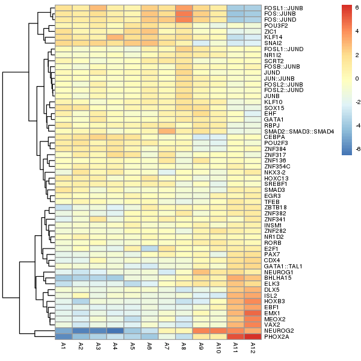

```r
options(repr.plot.width=5, repr.plot.height=5)
dev.scores %>% filter(is_hit == "Yes") %>%
                select(gene_name, A1:A12) %>% arrange(gene_name) %>%
                column_to_rownames('gene_name')  %>%
                pheatmap(cluster_rows = T, show_rownames = T, cluster_cols = F, fontsize=6)
```

##### Heatmap for all TF (~1800) motif binding sites accessibility

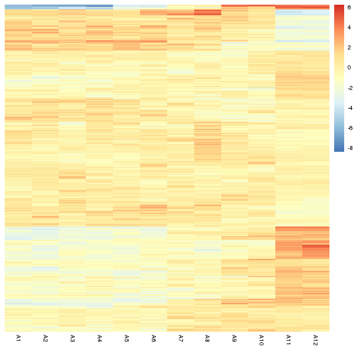

```r
dev.scores %>%  filter(is_tf == "Yes") %>% select(gene_name, A1:A12)  %>% column_to_rownames('gene_name')  %>%
                        pheatmap(cluster_rows = T, show_rownames = F, cluster_cols = F, show_colnames=T, fontsize=6, treeheight_row=0)
```

```r
dev.scores %>% head
```

A tibble: 6 × 15

| gene_name <chr> | is_hit <chr> | is_tf <chr> | A1 <dbl> | A2 <dbl> | A3 <dbl> | A4 <dbl> | A5 <dbl> | A6 <dbl> | A7 <dbl> | A8 <dbl> | A9 <dbl> | A10 <dbl> | A11 <dbl> | A12 <dbl> |
| --- | --- | --- | --- | --- | --- | --- | --- | --- | --- | --- | --- | --- | --- | --- |
| ALX3 | No | Yes | -1.6384447 | -2.8446575 | -1.8827820 | -2.0961426 | -2.4567807 | -1.8130310 | 0.019649268 | 0.45831325 | 0.11274948 | 0.4392262 | 2.0574681 | 2.4345177 |
| AR | No | Yes | -1.8444513 | -1.2043915 | -1.3958242 | -1.4052146 | -1.0476070 | -0.7026961 | 0.996668890 | -0.08521765 | 1.58243067 | 1.4792939 | 0.9980039 | 0.1986967 |
| ARGFX | No | Yes | -2.1638243 | -2.7691897 | -2.1060805 | -2.0190687 | -2.7565552 | -3.0051652 | -0.001254575 | -0.25617104 | 1.03010236 | 0.5883838 | 2.5788242 | 3.0302946 |
| ARNT::HIF1A | No | Yes | 0.3273486 | 0.8879503 | 0.3463007 | 0.6437213 | -0.4228751 | 0.3061073 | -0.569705629 | -0.01452481 | -0.07988779 | 0.3860256 | -0.6696215 | -0.2358546 |
| ARNT2 | No | Yes | -0.4369646 | 0.8230277 | 0.2317603 | -0.2771520 | -1.2620006 | 0.1065155 | -1.980499557 | -2.41117116 | -0.66115140 | -0.6514473 | 1.3497916 | 1.3835475 |
| ASCL1 | No | Yes | -1.8865133 | -2.4921049 | -1.5194095 | -1.8064744 | -1.1076559 | -0.6505122 | 1.132335574 | -0.49695308 | 0.24476842 | 0.1323490 | 1.8266022 | 1.7238736 |

**ZBTB18 sequence logo**

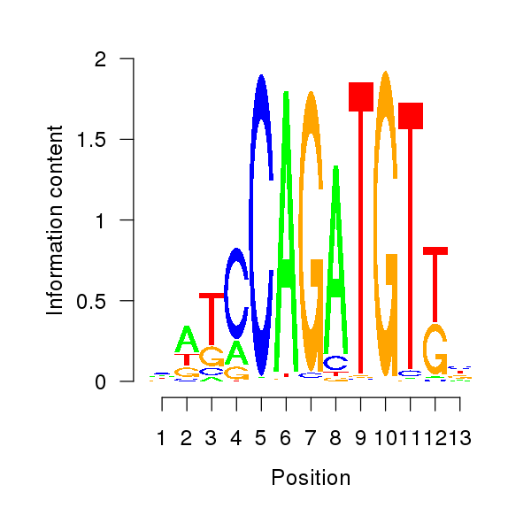

```r
#sequence logo for ZBTB18
mx <- toPWM(Matrix(jaspar_2020)$ZBTB18, "prob" )
seqLogo::seqLogo(mx)
```

## Find TF targets

Use motifMatchr to match all promoter region first. Then intersect ATACseq peaks with promoter region (that are matched with a certain motif). The result is a list of peaks from ATACseq that belong to a list of genes' promoter region, with which the motif(TF) can bind to. In otherwords, given a TF motif, we now have a list of genes that have been assayed to show different binding accessibility to the TF motif.

zbtb18 motif ID `MA0698.1`

#### Support functions for this section

```r
getSubjectGRanges <- function(feature.granges, matchMotifResult, motif_id) {
    # inputs:
    # feature.granges = GRange object of feature, e.g. promoter
    # matchMotifResult - matchMotifs result of feature region, and motifs
    # motif.db - motifs, such as jaspar 2018 motifs
    # hitgenelist - hit gene list, a vector
    # motif_lookup - motif look up dataframe, indicating whether a motif is hit or not, and gene name
    # outputs:
    # matched_features: the GRange object of features that match to the specified motif (motif_id)

    motif_matches_matrix <- motifMatches(matchMotifResult) # matrix of matching motifs and peak GRanges
    motif_match_per_feature_idx <- motif_matches_matrix[, motif_id] %>% as.matrix %>% which # row index of matched feature granges
    matched_features <- feature.granges[motif_match_per_feature_idx]
    return(matched_features) # return feature promoter (GRanges) that match to JASPAR motifs
}
```

```r
findDeviationPerTarget <- function(devScore.peak, motif_ix, motif_id, feature_granges, min.overlap = 10, hitgenelist) {
    # inputs:
    # deviationResult: chromVar computed deviation
    # fragment.counts: RangedSummarizedExperiment from chromVAR, including filtered peaks and readcounts
    # subject.granges: GRange object that you want to intersect with. For example, Promoter ranges. Note, it should have gene_name or gene_id included in mcols
    # min.overlap: minimum overlap for GenomicRanges::findOverlaps method
    # output:
    # deviation.score.per.target: given genomic feature region, e.g. promoter region that maps to ZBTB18 motif, chromVAR deviation results, and fragment counts, report the genes
    # that are potential targets of the given motif (determined by subject.granges), and report deviation score.

    peak_idx <- which(motif_mx[, motif_id])  # indices of peaks that match a particular motif
    devScore.peak.motif <- devScore.peak[peak_idx] # deviation scores of peaks that match to a particular motif

    # find overlap between query (a motif matched peak set), and subject (such as promoters)
    hitTarget.overlap <- GenomicRanges::findOverlaps(query = devScore.peak.motif, subject = feature_granges, minoverlap = min.overlap, ignore.strand = T)

    # get gene_names from the feature granges
    gene_names <- feature_granges[subjectHits(hitTarget.overlap)] %>%
                    elementMetadata %>%
                    as.data.frame %>%
                    pull(gene_name)

    # concatenate overlap results (peaks that are within promoter or gene regions).
    # Output dataframe includes peaks that are within genomic feature in subject.granges, and its annotation (gene_name)
    target_devScore.peak.motif <- devScore.peak.motif[queryHits(hitTarget.overlap)] %>%
                                    mcols  %>% # deviation scores stored in mcols
                                    as.data.frame %>%
                                    add_column('gene_name' = gene_names) %>%
                                    dplyr::select(A1:gene_name) %>%
                                    filter(gene_name %in% hitgenelist) %>%
                                    group_by(gene_name) %>%
                                    summarise_all(sum) %>%
                                    arrange(gene_name)
    return(target_devScore.peak.motif)
}
```

```r
getHitTF <- function(dev.score.df, motif_lookup, A.cols, B.cols) {
    ######################### FUNCTION:
    #### Select Hit TF's motifs that has increasing deviation scores, return a list of such motif names
    # dev.score.df: deviation scores matrix
    # A.cols: vector, the column names of ES, eg. c("A1","A2")
    # B.cols: vector, the column names of another time point, eg. c("A11","A12")

    dev.scores.hit <- dev.score.df %>% filter(is_hit == "Yes") %>% dplyr::select(gene_name, A.cols, B.cols)

    # calculate mean difference between two time points
    dev.mean.A <- dplyr::select(dev.scores.hit, A.cols) %>% apply(MARGIN = 1, mean) # mean of time point A
    dev.mean.B <- dplyr::select(dev.scores.hit, B.cols) %>% apply(MARGIN = 1, mean) # mean of time point B
    dev.BvsA <- dev.mean.B - dev.mean.A # B - A
    dev.scores.hit <- add_column(dev.scores.hit, "B_A"= dev.BvsA) # add difference of means as a column

    # select TF motifs that have increasing accessibility
    TF <- dev.scores.hit %>% dplyr::filter(dev.BvsA > 0) %>% pull(gene_name)
    TF_motif_ids <- motif_lookup %>% filter(gene_name %in% TF) %>% pull(motif)
    return(TF_motif_ids) # return hit TF jaspar motif name
}
```

```r
getTargetDeviationScore <- function(TF_motif_ids, devScore.peak, motif_ix, feature_granges, min.overlap = 10, hitgenelist, A.cols, B.cols, motif_lookup) {
    ######################### FUNCTION:
    #### Based on previously selected TF_motif_id, find the genes that has peaks in its promoter region (or feature region) that
    #### have matches to given jaspar motif. Result is a dataframe of Source TF name and Target Gene name (TF could bind to based on motif match).
    #### Return dataframe columns: 1. TF 2. target 3. deviation difference at given time point (eg. 5D - ES)
    # TF_motif_ids: a vector of motif names
    # devScore.peak: peak's deviation scores calculated earlier
    # motif_ix: each peak's motif matching result
    # feature_granges: a GRange object of features, e.g. promoters
    # hitgenelist: list of git genes
    # A.cols: eg. for ES: c("A1", "A2")
    # B.cols: eg. for 5D: c("A11", "A12")
    # motif_lookup: motif_lookup dataframe

    target_genes <- list()
    for (motif_id in TF_motif_ids) {
        target <- findDeviationPerTarget(devScore.peak = devScore.peak, motif_ix = motif_ix, motif_id = motif_id, feature_granges = feature_granges, min.overlap = min.overlap, hitgenelist = hitgenelist)
        target.A.mean <- target %>% dplyr::select(A.cols) %>% apply(1, mean)
        target.B.mean <- target %>% dplyr::select(B.cols) %>% apply(1, mean)
        target.BvsA <- target.B.mean - target.A.mean
        target <- target %>% add_column("B_A"=target.BvsA)
        target <- target %>% filter(`B_A` > 0)
        target_genes[[motif_lookup[motif_lookup$motif == motif_id,'gene_name']]] <- target
    }
    # expand list to dataframe
    target_genes.df <- do.call(rbind,target_genes)
    target_genes.df <- target_genes.df %>% rownames_to_column("TF") %>% mutate_at("TF", ~ str_remove(.x, "\\.[0-9]+$"))
    return(target_genes.df)
}
```

```r
combineRnaProfileWithAtac <- function(target_genes.df, RNA_temporal_file) {
    ######################### FUNCTION:
    #### Taking the RNA seq temporal expression profile (code 1 - 31), and augment the TF-Target deviation score change dataframe.
    #### Returning a dataframe with source and target gene expression temporal profile
    # target_genes.df - returned dataframe from getTargetDeviationScore function
    # RNA_temporal_file - "../RNAseq_WT_temporal.csv"

    rna_temporal <- read.table(RNA_temporal_file, sep = ",", stringsAsFactors = F, header=T)
    tf_target_intera <- target_genes.df %>% dplyr::select(TF, gene_name, B_A)
    out.nodes <- tf_target_intera %>% pull(TF) %>% unique
    in.nodes <- tf_target_intera %>% pull(gene_name) %>% unique
    all.nodes <- c(out.nodes, in.nodes) %>% unique

    tf_target_intera <- tf_target_intera %>% left_join(rna_temporal[,2:3], by = c("TF" = "gene_name")) %>%
                        rename("B_A"="devS.dif", "expr.flag"="source.temporal") %>%
                        left_join(rna_temporal[,2:3], by = c("gene_name" = "gene_name")) %>%
                        rename("expr.flag"="target.temporal")
    return(tf_target_intera)
}
```

```r
getBindingTargetsMatrix <- function(motif_name, match_feature_motif, devScore.peak, min.overlap = 10, motif_lookup, tflist) {
    # provide a genecode gene name, output the names and ATAC read counts of its regulator TFs that bind in it's gene body + upstream 2kb region
    # devScore.peak can be either deviation score or count matrix, it must be a GRange object
    # feature_granges is a grange object with gene name or gene id in metacolumn
    # hitgenelist is a list of gene names
    # motif_ix is

    feature_motif_matches <- motifMatches(match_feature_motif)
    # get the row index of all the target genes that the given motif can bind to
    row.idx <- feature_motif_matches[ , motif_name] %>% which(.)
    # get the granges of these target genes
    targets.granges <- rowRanges(match_feature_motif)[row.idx]

    # intersect with ATACseq peak data (can either use counts or deviation score)
    atac.overlap <- GenomicRanges::findOverlaps(query = devScore.peak,
                                                subject = targets.granges,
                                                minoverlap = min.overlap,
                                                ignore.strand = T)
    overlap.gene_names <- targets.granges[subjectHits(atac.overlap), ] %>%
                            as.data.frame %>%
                            pull(gene_name) # regulators intersect with peaks
    overlap.targets.mx <- devScore.peak[queryHits(atac.overlap),] %>%
                                    mcols  %>% # deviation scores /counts stored in mcols
                                    as.data.frame %>%
                                    add_column('gene_name' = overlap.gene_names) %>%
                                    dplyr::select(A1:gene_name) %>%
                                    filter(gene_name %in% tflist) %>%
                                    group_by(gene_name) %>%
                                    summarise_all(sum) %>%
                                    arrange(gene_name)
    return(overlap.targets.mx)
}
```

```r
getRegulatorsMatrix <- function(gene_name, match_feature_motif, devScore.peak, feature_granges, min.overlap = 10, motif_lookup, tflist) {
    # provide a genecode gene name, output the names and ATAC read counts of its regulator TFs that bind in it's gene body + upstream 2kb region
    # devScore.peak can be either deviation score or count matrix, it must be a GRange object
    # feature_granges is a grange object with gene name or gene id in metacolumn
    # hitgenelist is a list of gene names
    # motif_ix is

    feature_motif_matches <- motifMatches(match_feature_motif)
    # get the row index that matches the gene_name
    row.idx <- which(rowRanges(match_feature_motif)$gene_name == gene_name)

    # get the motif names that bind to the target gene
    regulators <- colnames(feature_motif_matches)[feature_motif_matches[row.idx,] %>% which(.)]
    # convert motif name to gene names
    regulators <- filter(motif_lookup, motif %in% regulators) %>% pull(gene_name)
    # get granges of binding regulators
    regulators.granges <- feature_granges[which(feature_granges$gene_name %in% regulators), ]
    # intersect with ATACseq peak data (can either use counts or deviation score)
    atac.overlap <- GenomicRanges::findOverlaps(query = devScore.peak, subject = regulators.granges, minoverlap = min.overlap, ignore.strand = T)
    overlap.gene_names <- regulators.granges[subjectHits(atac.overlap), ] %>% as.data.frame %>% pull(gene_name) # regulators intersect with peaks
    overlap.regulators.mx <- devScore.peak[queryHits(atac.overlap),] %>%
                                    mcols  %>% # deviation scores /counts stored in mcols
                                    as.data.frame %>%
                                    add_column('gene_name' = overlap.gene_names) %>%
                                    dplyr::select(A1:gene_name) %>%
                                    filter(gene_name %in% tflist) %>%
                                    group_by(gene_name) %>%
                                    summarise_all(sum) %>%
                                    arrange(gene_name)
    return(overlap.regulators.mx)
}
```

```r
getRegulatorsMatrixFromAnnotation <- function(gene_name, match_feature_motif, feature_granges, min.overlap = 10, motif_lookup) {
    # provide a genecode gene name, output the names and ATAC read counts of its regulator TFs that bind in it's gene body + upstream 2kb region
    # feature_granges is a grange object with gene name or gene id in metacolumn
    # match_feature_motif, matchMotifs object

    # get motif matching result, a logic matrix
    feature_motif_matches <- motifMatches(match_feature_motif)
    # get the row index that matches the gene_name
    row.idx <- which(rowRanges(match_feature_motif)$gene_name == gene_name)

    # get the motif names that bind to the target gene
    regulators <- colnames(feature_motif_matches)[feature_motif_matches[row.idx,] %>% which(.)]
    # convert motif name to gene names
    regulators <- filter(motif_lookup, motif %in% regulators) %>% pull(gene_name)
    # get granges of binding regulators
    regulators.granges <- feature_granges[which(feature_granges$gene_name %in% regulators), ]
    # intersect with ATACseq peak data (can either use counts or deviation score)
    atac.overlap <- GenomicRanges::findOverlaps(query = devScore.peak, subject = regulators.granges, minoverlap = min.overlap, ignore.strand = T)
    overlap.gene_names <- regulators.granges[subjectHits(atac.overlap), ] %>% as.data.frame %>% pull(gene_name) # regulators intersect with peaks
    overlap.regulators.mx <- devScore.peak[queryHits(atac.overlap),] %>%
                                    mcols  %>% # deviation scores /counts stored in mcols
                                    as.data.frame %>%
                                    add_column('gene_name' = overlap.gene_names) %>%
                                    dplyr::select(A1:gene_name) %>%
                                    filter(gene_name %in% tflist) %>%
                                    group_by(gene_name) %>%
                                    summarise_all(sum) %>%
                                    arrange(gene_name)
    return(overlap.regulators.mx)
}
```

```r
rna_temporal <- read.table("../RNAseq_WT_temporal.csv", sep = ",", stringsAsFactors = F, header=T)
```

### Find targets of Neurog1/2

##### 1 First load motifs and calculate peak deviation score

```r
# use previous loaded jaspar_2020
# use previous calculated motif_ix
```

```r
# calculate deviation scores for each peak
dev.peak <- computeDeviations(object = fragment_counts.filtered)
```

```
Annotations not provided, so chromVAR being run on individual peaks...
```

```r
motif_mx <- motifMatches(motif_ix)
```

```r
# get deviation score per peak
devScore.peak <- deviationScores(dev.peak)

# Above dataframe doesn't have peak coordinates. Thus get coordinates
devScore.peak <- rowRanges(motif_ix) %>% as.data.frame %>%
                        dplyr::select(seqnames, start, end) %>%
                        cbind(devScore.peak) %>%
                        makeGRangesFromDataFrame(keep.extra.columns = T)
```

##### 2 Then get GRanges of the promoters that match interested TF motifs

```r
# get annotated promoter region bed
gene_region <- read.table("Protein_coding_genes_Up_2k.bed", header = F, stringsAsFactors = F,
                              col.names = c("seqname","start","end","gene_id","gene_name","strand")) %>%
                                dplyr::select(seqname, start, end, strand, gene_id, gene_name)
# convert to GRanges object
gene_region <- GenomicRanges::makeGRangesFromDataFrame(gene_region, keep.extra.columns = T)
```

```r
motif_lookup %>% filter(str_detect(motif, "NEUROG"))
```

A data.frame: 3 × 4

| motif <chr> | gene_name <chr> | is_hit <chr> | is_tf <chr> |
| --- | --- | --- | --- |
| NEUROG2 | NEUROG2 | Yes | Yes |
| NEUROG1 | NEUROG1 | Yes | Yes |
| NEUROG2(var.2) | NEUROG2 | Yes | Yes |

#### 3 For each time point:

- get TF of interest
- get binding targets of each TF, that are within promoter region
- get diviation scores of such target genes
- get pair-wise (TF-Target) diviation score change for each time point (Get only positive changing pairs)
- agument with RNA temporal profile
- save to csv

```r
library(WriteXLS)
```

```r
A_cols <- c("A1", "A2")
B_cols <- list("H1_ES"=c("A3", "A4"), "H4_ES"=c("A5", "A6"), "H16_ES"=c("A7", "A8"), "D1_ES"=c("A9", "A10"), "D5_ES"=c("A11", "A12"))
```

```r
source_tf_motif_names
```

1. 'NEUROG2'

2. 'NEUROG1'

3. 'NEUROG2(var.2)'

4. 'ZBTB18'

### A. Know regulators, find their targets

```r
FOUND_TARGETS <- list()
Regulators <- c("NEUROG2", "NEUROG1", "NEUROG2(var.2)", "ZBTB18")
```

```r
for (regulator in Regulators) {
    y <- getBindingTargetsMatrix(motif_name = regulator, match_feature_motif = match_feature_motif, devScore.peak = my_counts_matrix.norm,
                             feature_granges = gene_region, min.overlap = 400, motif_lookup = motif_lookup, tflist = tflist)
    item <- paste0(regulator, "_as_regulator")
    regulator.name <- motif_lookup %>% filter(motif == regulator) %>% pull(gene_name) %>% .[1]
    y["regulator"] <- regulator.name
    FOUND_TARGETS[[item]] <- y
}
```

```r
FOUND_TARGETS <- do.call(rbind, FOUND_TARGETS)
FOUND_TARGETS <- FOUND_TARGETS %>% group_by(regulator, gene_name) %>% summarise_all(mean)
```

```r
match_feature_motif <- matchMotifs(jaspar_2020, gene_region, genome = BSgenome.Hsapiens.UCSC.hg38, out = "scores")
```

```r
motif_ix_scores <- matchMotifs(jaspar_2020, fragment_counts.filtered, genome = BSgenome.Hsapiens.UCSC.hg38, out = "scores")
```

use motifCounts to get counts of matching motif in peak

```r
motif_ix %>% rowRanges(.) %>% .[c(140,243, 265, 266, 267)]
```

```
GRanges object with 5 ranges and 1 metadata column:
      seqnames          ranges strand |      bias
         <Rle>       <IRanges>  <Rle> | <numeric>
  [1]     chr1 2144327-2144826      + |     0.628
  [2]     chr1 3790171-3790670      + |     0.618
  [3]     chr1 4365626-4366125      + |     0.592
  [4]     chr1 4476962-4477461      + |     0.546
  [5]     chr1 4494209-4494708      + |     0.588
  -------
  seqinfo: 24 sequences from an unspecified genome; no seqlengths
```

```r
motif_ix_scores %>% motifMatches %>% .[,"NEUROG2"] %>% which(.) %>% head
```

1. 140

2. 243

3. 265

4. 266

5. 267

6. 277

```r
neurog2.motif.counts <- motifCounts(motif_ix_scores) %>% .[,"NEUROG2"]
```

### B. Know targets, find their regulators

```r
FOUND_REGULATORS <- list()
Targets <- c("ZBTB18", "INSM1", "PHOX2A", "ISL2")
```

```r
for (target in Targets) {
    x <- getRegulatorsMatrix(gene_name = target, match_feature_motif = match_feature_motif, devScore.peak = my_counts_matrix.norm,
                         feature_granges = gene_region, min.overlap = 10, motif_lookup = motif_lookup, tflist = tflist)
    item <- paste0(target, "_as_target")
    target.name <- motif_lookup %>% filter(motif == target) %>% pull(gene_name) %>% .[1]
    x["target"] <- target.name
    FOUND_REGULATORS[[item]] <- x
}
```

```r
FOUND_REGULATORS <- do.call(rbind, FOUND_REGULATORS)
FOUND_REGULATORS <- FOUND_REGULATORS %>% group_by(target, gene_name) %>% summarise_all(mean)
```

```r
WriteXLS(list(Targets=FOUND_TARGETS, Regulators=FOUND_REGULATORS), "Set_of_regulators_counts_by_time.xls")
```

```r
getRegulatorsMatrix(gene_name = "INSM1", match_feature_motif = match_feature_motif, devScore.peak = my_counts_matrix.norm,
                         feature_granges = gene_region, min.overlap = 10, motif_lookup = motif_lookup, tflist = tflist)
```

A tibble: 64 × 13

| gene_name <chr> | A1 <dbl> | A2 <dbl> | A3 <dbl> | A4 <dbl> | A5 <dbl> | A6 <dbl> | A7 <dbl> | A8 <dbl> | A9 <dbl> | A10 <dbl> | A11 <dbl> | A12 <dbl> |
| --- | --- | --- | --- | --- | --- | --- | --- | --- | --- | --- | --- | --- |
| ASCL1 | 4.768962 | 3.862620 | 3.250146 | 2.553573 | 0.9992412 | 2.534802 | 3.954998 | 2.878414 | 3.493347 | 5.819235 | 12.421283 | 13.118919 |
| BARX1 | 35.950638 | 34.548993 | 27.219971 | 27.876510 | 35.7728341 | 37.177098 | 35.362332 | 49.271668 | 34.841543 | 47.523756 | 63.862961 | 76.431962 |
| BATF | 7.336865 | 9.441961 | 11.984913 | 5.958338 | 7.9939294 | 10.984143 | 13.726169 | 13.037520 | 7.630206 | 8.867406 | 5.896973 | 4.277908 |
| CTCFL | 12.472670 | 9.871141 | 19.500875 | 9.575900 | 13.3898318 | 14.223056 | 17.215872 | 17.270482 | 15.903923 | 18.289026 | 13.299556 | 8.698414 |
| E2F6 | 11.188719 | 8.583601 | 7.922231 | 8.086316 | 11.3913494 | 12.955655 | 8.375289 | 10.836381 | 13.421808 | 13.855322 | 7.653518 | 11.550352 |
| EGR1 | 2.017638 | 1.287540 | 1.421939 | 3.191967 | 3.1975718 | 1.971513 | 1.163235 | 1.862503 | 2.574045 | 1.662639 | 5.269635 | 5.418684 |
| FOS | 37.234589 | 31.759323 | 29.657581 | 39.580388 | 24.1816365 | 34.642296 | 36.060273 | 29.800047 | 26.935547 | 28.264858 | 32.245149 | 33.367685 |
| FOSL1 | 6.603178 | 6.437701 | 6.094023 | 5.319945 | 2.3981788 | 5.773716 | 3.954998 | 1.693184 | 6.159323 | 3.325277 | 3.889493 | 2.994536 |
| FOXC2 | 5.135805 | 4.935570 | 5.890889 | 6.171136 | 7.7940812 | 5.069604 | 9.538524 | 8.465922 | 11.123553 | 13.578216 | 39.647732 | 40.497532 |
| FOXL1 | 5.869492 | 4.077210 | 5.687755 | 4.894349 | 4.5965094 | 7.041117 | 15.819991 | 16.254571 | 23.258339 | 28.541964 | 62.984689 | 65.451997 |
| HES1 | 9.721346 | 14.162941 | 11.781779 | 12.555069 | 9.9924118 | 12.814833 | 9.073230 | 8.804559 | 8.733368 | 8.313193 | 8.029920 | 8.128026 |
| HES2 | 34.483265 | 34.119813 | 35.751604 | 34.898837 | 42.5676741 | 35.205585 | 31.872629 | 38.604606 | 28.038709 | 29.788943 | 20.576671 | 19.393184 |
| HEY1 | 8.987659 | 4.935570 | 8.937901 | 9.363103 | 6.1952953 | 4.647137 | 11.632346 | 6.095464 | 13.421808 | 20.367324 | 6.273375 | 9.126204 |
| HEY2 | 21.460330 | 21.244412 | 22.954155 | 24.684543 | 20.9840647 | 26.897067 | 29.313512 | 29.969365 | 25.740454 | 30.758816 | 22.835086 | 31.228731 |
| HOXD4 | 3.668432 | 6.652291 | 4.265816 | 5.958338 | 5.7955988 | 4.506315 | 4.885585 | 3.555687 | 4.320719 | 5.126469 | 3.136688 | 2.851939 |
| JDP2 | 23.477967 | 21.459002 | 18.282070 | 17.023823 | 20.5843682 | 26.052133 | 24.893221 | 29.292091 | 25.464663 | 26.325113 | 36.385577 | 38.073384 |
| JUN | 54.476221 | 48.711934 | 45.095774 | 55.540222 | 62.7523459 | 54.920713 | 67.700255 | 72.976251 | 61.960950 | 70.662144 | 86.321645 | 85.130376 |
| JUNB | 14.123465 | 8.369011 | 20.516546 | 11.491080 | 12.3905906 | 17.602793 | 14.191462 | 8.296604 | 11.307414 | 8.174640 | 10.288336 | 7.557638 |
| JUND | 52.642005 | 50.214064 | 44.080103 | 47.666704 | 44.9658529 | 42.669169 | 41.643799 | 45.546662 | 41.552447 | 40.734648 | 38.643992 | 43.919859 |
| KLF15 | 10.638454 | 9.012781 | 8.734767 | 13.619058 | 6.9946882 | 9.012630 | 16.052638 | 11.513654 | 8.733368 | 10.807152 | 4.893233 | 7.985429 |
| KLF16 | 13.756622 | 19.527692 | 17.875802 | 11.278283 | 20.5843682 | 22.672397 | 18.611754 | 22.180717 | 29.325732 | 29.927496 | 18.443724 | 13.831904 |
| KLF3 | 17.608476 | 12.446221 | 21.735350 | 18.939003 | 22.3830023 | 20.137595 | 13.028228 | 15.915934 | 16.547435 | 14.686642 | 9.410063 | 10.837368 |
| KLF4 | 44.021189 | 50.214064 | 42.251896 | 48.730693 | 49.1626659 | 43.514103 | 43.737622 | 52.488719 | 46.516678 | 46.276777 | 44.666433 | 48.482961 |
| KLF5 | 17.791897 | 21.673592 | 17.063266 | 16.811025 | 11.1915012 | 11.547432 | 12.795581 | 15.746616 | 17.558667 | 16.626387 | 9.410063 | 10.266980 |
| KLF9 | 15.040573 | 16.094251 | 13.000583 | 14.044654 | 10.5919565 | 14.082234 | 12.330287 | 13.037520 | 12.778297 | 15.379408 | 21.580411 | 20.676557 |
| LMX1A | 99.047675 | 115.449430 | 108.270484 | 112.782827 | 101.5229035 | 115.755964 | 99.107590 | 98.543336 | 92.297914 | 81.607849 | 91.842216 | 88.124912 |
| MAZ | 36.134059 | 28.755062 | 35.345336 | 34.473241 | 27.3792082 | 31.121737 | 20.472929 | 24.212538 | 29.509592 | 28.680517 | 18.694659 | 19.250587 |
| MEF2A | 7.520286 | 7.939831 | 13.609986 | 13.831856 | 5.9954471 | 9.857564 | 13.726169 | 15.915934 | 16.823225 | 10.945705 | 20.576671 | 24.241481 |
| MEF2B | 66.031783 | 57.939305 | 53.018004 | 62.562549 | 66.9491588 | 66.608967 | 67.700255 | 63.833055 | 61.317439 | 60.824866 | 53.323691 | 55.185017 |
| MEF2C | 50.440946 | 44.205544 | 53.830541 | 47.666704 | 36.7720753 | 39.430255 | 31.872629 | 39.112561 | 41.644377 | 38.794903 | 36.009175 | 37.502996 |
| ⋮ | ⋮ | ⋮ | ⋮ | ⋮ | ⋮ | ⋮ | ⋮ | ⋮ | ⋮ | ⋮ | ⋮ | ⋮ |
| NFE2 | 33.382735 | 28.969652 | 27.829374 | 24.258948 | 37.171772 | 33.093250 | 25.591162 | 35.895511 | 32.911009 | 28.680517 | 29.359397 | 28.8045827 |
| NFKB1 | 30.631411 | 28.969652 | 35.751604 | 30.430083 | 25.580574 | 30.558448 | 30.709394 | 29.461410 | 31.164335 | 30.204603 | 34.503565 | 30.2305522 |
| NFKB2 | 8.804238 | 4.506390 | 11.578645 | 12.342272 | 10.392108 | 12.674011 | 9.771171 | 10.497744 | 10.663902 | 11.222811 | 20.325736 | 23.9562866 |
| NFYA | 5.319227 | 5.150160 | 6.094023 | 4.894349 | 3.797116 | 6.477828 | 3.722351 | 3.386369 | 3.401417 | 1.385532 | 1.756545 | 3.5649236 |
| NFYC | 42.003551 | 57.724715 | 40.423689 | 45.964322 | 47.763728 | 45.063149 | 56.533203 | 58.584183 | 54.606535 | 50.849033 | 73.649427 | 68.1613393 |
| NRF1 | 28.797194 | 27.467522 | 27.626240 | 21.066981 | 14.988618 | 26.192955 | 31.639982 | 22.350035 | 28.406430 | 19.397451 | 25.093502 | 25.2396591 |
| OTX1 | 23.294546 | 26.609162 | 18.688339 | 20.428588 | 21.983306 | 18.447727 | 16.517932 | 16.085253 | 17.834457 | 16.210727 | 8.908193 | 7.8428319 |
| PBX2 | 5.502649 | 6.652291 | 4.062682 | 5.532742 | 7.993929 | 7.604406 | 4.652938 | 4.402280 | 8.733368 | 8.867406 | 15.056101 | 9.2688014 |
| PLAG1 | 57.044124 | 45.278494 | 46.517712 | 50.007480 | 58.355685 | 50.977687 | 57.231143 | 60.446686 | 63.615694 | 69.969378 | 89.583800 | 95.2547587 |
| PLAGL2 | 11.555562 | 8.798191 | 10.156706 | 10.427092 | 8.793322 | 9.294274 | 10.701759 | 11.175018 | 9.376880 | 7.620427 | 4.642298 | 3.9927144 |
| POU4F1 | 11.555562 | 10.944091 | 8.531633 | 9.363103 | 6.594992 | 11.265787 | 2.791763 | 4.402280 | 2.022464 | 2.216852 | 1.003740 | 1.4259694 |
| PRDM4 | 3.851854 | 5.150160 | 6.906560 | 2.127978 | 2.997724 | 4.083848 | 4.187645 | 3.894324 | 4.688440 | 3.740937 | 2.007480 | 1.8537603 |
| RARA | 67.866000 | 60.514385 | 71.096940 | 81.501552 | 66.549462 | 69.566236 | 66.769667 | 57.568272 | 63.615694 | 56.945375 | 97.990123 | 99.9604579 |
| RREB1 | 126.010653 | 147.423343 | 125.943152 | 140.872135 | 148.087542 | 142.934676 | 144.473740 | 122.586556 | 132.287548 | 126.221987 | 156.708917 | 150.7249700 |
| SOX8 | 1.467373 | 1.716720 | 1.828207 | 1.276787 | 4.196813 | 1.971513 | 5.350879 | 1.862503 | 3.033696 | 4.572256 | 5.646038 | 4.2779083 |
| SOX9 | 20.910065 | 18.669332 | 23.969826 | 19.577396 | 26.379967 | 19.292661 | 24.660574 | 26.413678 | 25.096943 | 20.782984 | 28.230189 | 20.5339600 |
| SP2 | 30.081146 | 28.325882 | 24.376094 | 30.430083 | 29.377691 | 30.980915 | 33.035863 | 35.048919 | 28.406430 | 38.379243 | 27.853787 | 22.8155111 |
| SP3 | 9.171081 | 13.304581 | 7.109694 | 9.363103 | 7.794081 | 9.012630 | 7.909995 | 7.450012 | 6.986695 | 5.957789 | 3.011220 | 0.9981786 |
| SP4 | 60.529135 | 72.102246 | 75.972159 | 66.818505 | 71.145972 | 55.624825 | 57.696437 | 48.086439 | 55.893557 | 60.132099 | 58.342391 | 54.6146296 |
| SP8 | 13.206357 | 11.158681 | 14.422522 | 13.831856 | 13.789528 | 8.026873 | 13.028228 | 7.788649 | 10.204251 | 11.777024 | 7.653518 | 12.8337250 |
| TCF12 | 156.091799 | 161.371694 | 130.818370 | 158.959947 | 136.896041 | 134.485335 | 142.845211 | 136.470669 | 143.043380 | 156.842250 | 101.503214 | 99.2474731 |
| TCF3 | 24.761919 | 21.244412 | 22.344753 | 23.620554 | 23.781940 | 25.066377 | 27.452337 | 35.218237 | 21.327805 | 21.060090 | 3.136688 | 3.1371328 |
| TCF4 | 146.920718 | 144.848262 | 135.287321 | 137.680168 | 129.301808 | 121.107213 | 124.698751 | 123.094511 | 125.576644 | 122.619604 | 142.782024 | 141.1709747 |
| TEAD3 | 38.151697 | 46.136854 | 44.689505 | 44.049142 | 37.571468 | 40.556834 | 37.223508 | 28.784136 | 37.507519 | 38.102137 | 45.168303 | 40.3549352 |
| TFAP2A | 33.382735 | 35.836533 | 41.845628 | 33.622050 | 32.375414 | 28.023646 | 28.615572 | 24.551175 | 27.854848 | 21.337197 | 24.842567 | 23.3858988 |
| VAX1 | 38.518540 | 48.068164 | 38.798616 | 48.943491 | 54.158872 | 51.118510 | 53.043499 | 54.859177 | 45.689306 | 55.559843 | 28.857527 | 32.3695063 |
| ZBTB7B | 95.562664 | 102.574029 | 90.597816 | 98.738173 | 99.124725 | 90.830410 | 90.499653 | 84.151268 | 79.703477 | 88.535510 | 92.344086 | 83.7044062 |
| ZIC1 | 116.105886 | 95.707148 | 98.926314 | 108.952467 | 114.313191 | 109.559781 | 117.951991 | 112.258131 | 116.199764 | 113.197984 | 135.128506 | 127.9094589 |
| ZNF148 | 19.075849 | 13.519171 | 12.188047 | 14.044654 | 16.787252 | 18.588549 | 13.726169 | 14.222750 | 15.720063 | 10.252939 | 8.029920 | 5.5612808 |
| ZNF263 | 8.620816 | 9.012781 | 10.156706 | 12.555069 | 12.990135 | 10.702498 | 14.191462 | 11.175018 | 15.628133 | 12.469790 | 8.155388 | 6.8446533 |

```r
FOUND_TARGETS %>% head
```

A grouped_df: 6 × 14

| regulator <chr> | gene_name <chr> | A1 <dbl> | A2 <dbl> | A3 <dbl> | A4 <dbl> | A5 <dbl> | A6 <dbl> | A7 <dbl> | A8 <dbl> | A9 <dbl> | A10 <dbl> | A11 <dbl> | A12 <dbl> |
| --- | --- | --- | --- | --- | --- | --- | --- | --- | --- | --- | --- | --- | --- |
| NEUROG1 | ABL1 | 198.82904 | 221.67149 | 206.587396 | 207.47784 | 207.44247 | 180.39342 | 154.477558 | 146.96841 | 145.617426 | 167.233742 | 163.609630 | 173.397884 |
| NEUROG1 | ADNP | 10.27161 | 13.94835 | 9.547303 | 12.34227 | 11.39135 | 11.40661 | 7.444702 | 14.56139 | 8.089857 | 5.542129 | 3.638558 | 6.416862 |
| NEUROG1 | AEBP2 | 98.31399 | 84.76306 | 84.300658 | 80.01197 | 84.93550 | 90.97123 | 101.666706 | 77.71717 | 85.495079 | 73.571762 | 54.954768 | 46.201410 |
| NEUROG1 | AFF1 | 170.76553 | 183.47447 | 181.195631 | 183.21889 | 167.47282 | 161.52322 | 138.424920 | 123.77179 | 148.283401 | 143.125481 | 119.570535 | 120.494418 |
| NEUROG1 | AFF3 | 410.68101 | 413.51497 | 384.939149 | 418.99884 | 416.28387 | 405.28670 | 398.058887 | 418.04725 | 414.789031 | 438.243849 | 455.196118 | 466.292007 |
| NEUROG1 | AFF4 | 31.54852 | 37.33866 | 34.532800 | 25.74853 | 28.57830 | 31.82585 | 26.521749 | 27.76823 | 27.211337 | 33.668434 | 30.237669 | 38.501175 |

```r
FOUND_REGULATORS %>% head
```

A grouped_df: 6 × 14

| target <chr> | gene_name <chr> | A1 <dbl> | A2 <dbl> | A3 <dbl> | A4 <dbl> | A5 <dbl> | A6 <dbl> | A7 <dbl> | A8 <dbl> | A9 <dbl> | A10 <dbl> | A11 <dbl> | A12 <dbl> |
| --- | --- | --- | --- | --- | --- | --- | --- | --- | --- | --- | --- | --- | --- |
| ZBTB18 | ASCL1 | 4.768962 | 3.862620 | 3.250146 | 2.553573 | 0.9992412 | 2.534802 | 3.954998 | 2.878414 | 3.493347 | 5.819235 | 12.421283 | 13.118919 |
| ZBTB18 | ATOH1 | 12.289249 | 12.660811 | 14.422522 | 23.833352 | 13.9893765 | 7.041117 | 14.424109 | 11.175018 | 14.341110 | 13.578216 | 17.314516 | 16.398649 |
| ZBTB18 | BARHL1 | 13.756622 | 20.171462 | 16.047595 | 20.641385 | 21.7834576 | 14.927168 | 14.424109 | 12.021610 | 16.639365 | 20.644430 | 24.591631 | 19.107991 |
| ZBTB18 | BCL6 | 43.654346 | 52.574554 | 44.689505 | 52.986649 | 51.9605412 | 46.048905 | 48.157913 | 42.329612 | 42.012098 | 35.746732 | 49.057795 | 59.320329 |
| ZBTB18 | BCL6B | 7.336865 | 6.866881 | 9.953572 | 5.319945 | 7.9939294 | 8.871807 | 13.958815 | 9.312515 | 13.054087 | 11.777024 | 9.660998 | 9.126204 |
| ZBTB18 | CDX2 | 9.537924 | 9.441961 | 10.156706 | 11.278283 | 10.1922600 | 8.449340 | 9.771171 | 10.836381 | 9.376880 | 9.421619 | 3.638558 | 4.705699 |

```r
FOUND_REGULATORS$gene_name %>% unique %>% sort %>% print
```

[output not shown]

```r
intersect(FOUND_REGULATORS$gene_name, FOUND_TARGETS[FOUND_TARGETS$regulator == "NEUROG1",]$gene_name) %>%
        sort %>% intersect(hitlist)
```

```r
intersect(FOUND_REGULATORS$gene_name, FOUND_TARGETS[FOUND_TARGETS$regulator == "NEUROG2",]$gene_name) %>%
        sort %>% intersect(hitlist)
```

1. 'ISL2'

2. 'NEUROG2'

3. 'PAX7'

4. 'ZNF282'

```r
intersect(FOUND_REGULATORS$gene_name, hitlist)
```

1. 'CEBPA'

2. 'EGR3'

3. 'INSM1'

4. 'ISL2'

5. 'KLF14'

6. 'NEUROG2'

7. 'PAX7'

8. 'PHOX2A'

9. 'ZNF282'